# Sydney Airbnb Price Intelligence

Predicting listing price tiers with interpretable machine learning

Aditya Moon

15 July 2026

# 1 Executive summary

Setting a nightly price is the single most consequential decision an Airbnb host makes, yet new hosts have little to anchor on: price too low and they forgo revenue, too high and the listing sits vacant. This project builds an end-to-end, reproducible machine-learning product that classifies a Sydney listing into one of three market price tiers — **Budget** (≤ $200/night), **Mid-Market** ($200–400) or **Premium** (> $400) — and explains the drivers behind that recommendation.

Trained on 17,701 live Sydney listings from the June 2026 Inside Airbnb snapshot (Cox, 2026), a gradient-boosted tree model (Chen & Guestrin, 2016) reaches **79.8 % accuracy** and **0.80 macro-F1** on a held-out test set, against a 39 % majority-class baseline. The model, its evaluation and the resulting interactive dashboard are all regenerated by a single command, and every design choice — from leakage-safe preprocessing to market-calibrated tier thresholds — is documented and tested. The live dashboard is available at https://sydney-airbnb-price-intelligence.streamlit.app/.

# 2 Introduction

## 2.1 Background

Short-term rental platforms such as Airbnb have reshaped urban accommodation markets, and a large body of hospitality research shows that nightly price is determined by a structured mix of location, capacity, host reputation and listing attributes rather than by intuition alone (Wang & Nicolau, 2017). Data-driven price modelling for Airbnb has since become a well-studied task, with machine-learning approaches consistently outperforming naïve heuristics (Kalehbasti et al., 2021). Framing the problem as **price-tier classification** rather than exact-dollar regression trades a small amount of precision for a decision that is directly actionable for a host and robust to the heavy right tail of nightly prices.

## 2.2 Problem statement and objectives

Given the observable attributes of a Sydney listing, predict its market price tier and surface the factors behind the prediction. The concrete objectives are:

1. Assemble a clean, reproducible feature set from the public Inside Airbnb snapshot.
2. Train and fairly compare several classifiers, selecting one on a held-out metric.
3. Serve the model through an interpretable, interactive dashboard usable by a non-technical host.
4. Guarantee reproducibility and correctness through configuration, tests and continuous integration.

# 3 Data

The analysis uses the **Inside Airbnb** Sydney dataset (Cox, 2026), a periodically published, openly licensed scrape of Airbnb listings released under a Creative Commons BY 4.0 licence. The June 2026 snapshot (`2026-06-16`) contains 20,573 raw listings described by roughly 90 columns spanning location, capacity, host profile, availability, reviews and free-text amenities. After cleaning (Section 4.1), **17,701 listings** remain for modelling.

Listed prices are *asking* prices rather than transacted rates — an important scope limitation discussed in Section 8. All raw data is fetched reproducibly at run time and is not committed to the repository.

# 4 Methodology

## 4.1 Data cleaning

Raw fields are parsed into analysis-ready types: currency strings (`"$1,234.00"`) into numeric AUD, `"t"`/`"f"` flags into booleans, and textual bathroom descriptions into numeric counts. Duplicate listing IDs are removed and nightly prices are bounded to a sane $10–$5,000 window to strip out `$0` placeholders and evident data-entry errors. Data manipulation throughout uses the pandas (McKinney, 2010) and NumPy (Harris et al., 2020) libraries.

## 4.2 Target definition

The three tiers are defined by nightly-price thresholds placed at round numbers near the market terciles: Budget ≤ $200, Mid-Market $200–400, and Premium > $400 (median = $291/night). This calibration keeps the classes deliberately balanced at roughly **31 / 39 / 30 %** (Figure 4.1), so that a high classification accuracy reflects genuine signal rather than the trivial majority-class prediction that an imbalanced target would reward.

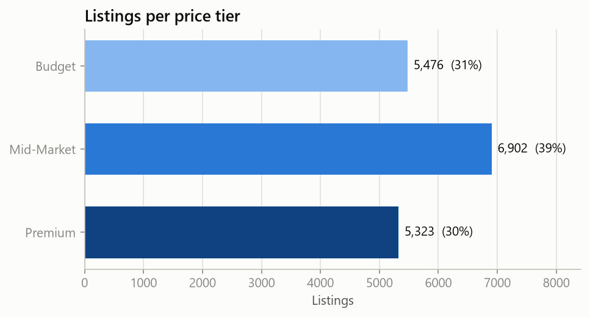

Figure 4.1: Distribution of listings across the three market price tiers. Round-number thresholds at the market terciles keep the classes balanced.

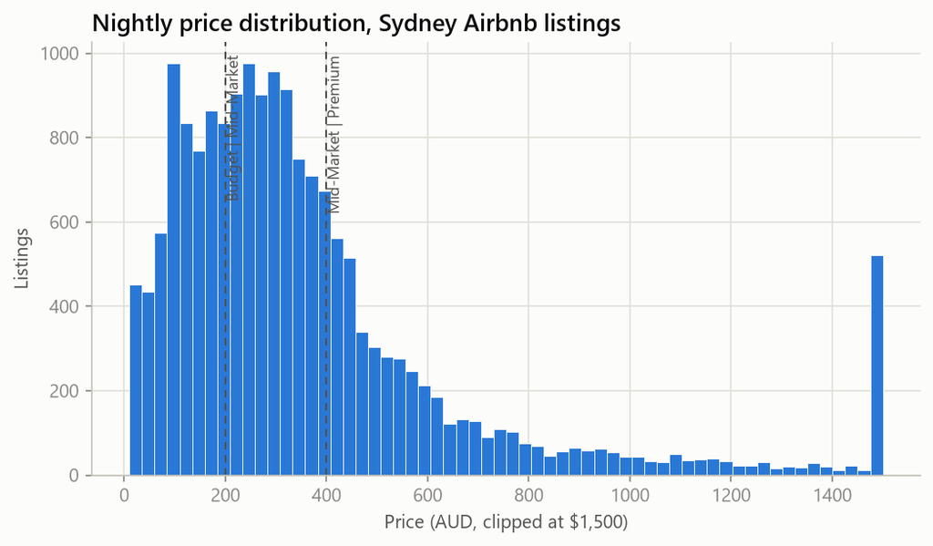

Figure 4.2: Distribution of nightly prices (AUD) across the snapshot, showing the characteristic heavy right tail that motivates tiered classification over exact-price regression.

## 4.3 Feature engineering

Twenty-four model features are derived from the cleaned data:

- **Location.** Great-circle (haversine) distance to the Sydney CBD and to the nearest of five major beaches, plus latitude/longitude and a popular-area flag.
- **Capacity.** Guests accommodated, bedrooms, beds, bathrooms, and coarse capacity buckets.
- **Amenities.** Total amenity count and six high-signal boolean flags (pool, air conditioning, free parking, washer, dishwasher, gym).
- **Host signals.** Superhost status, identity verification, host listing count and a host-experience bucket.
- **Reputation & availability.** Review count, reviews per month, review score, minimum nights and yearly availability.

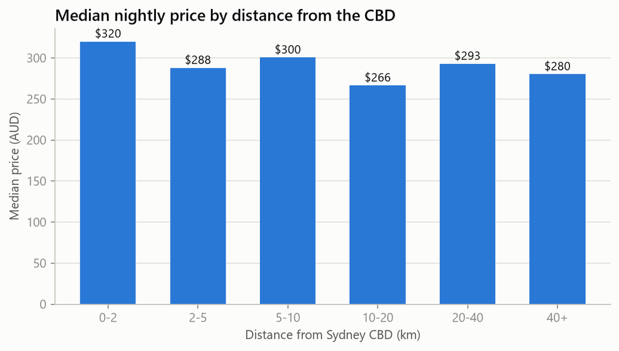

## 4.4 Modelling approach

All preprocessing — median/mode imputation, standardisation and one-hot encoding — is encapsulated inside a scikit-learn `Pipeline` (Pedregosa et al., 2011) so that every transformation is fitted on the training split **only** and is persisted alongside the estimator. This prevents test-set information from leaking into training, a common and silent source of over-optimistic results.

The data is split 80/20 with stratification on the tier label, and four candidate classifiers are compared under identical 5-fold cross-validation on the training split:

1. a majority-class **baseline**,
2. **logistic regression**,
3. a **random forest**, and
4. **gradient-boosted trees (XGBoost)** (Chen & Guestrin, 2016).

The final model is selected by **macro-F1**, which weights all three tiers equally and is therefore insensitive to residual class imbalance. The selected artifact is serialised with its metrics, snapshot date, training timestamp and exact library versions to keep results auditable.

# 5 Results

## 5.1 Model comparison

XGBoost was selected, reaching 79.8 % test accuracy and 0.80 macro-F1 (Table 5.1, Figure 5.1). All learned models improve dramatically on the 39 % baseline; the tree ensembles edge out logistic regression, consistent with the non-linear, interaction-heavy structure of pricing data reported in the literature (Kalehbasti et al., 2021).

Table 5.1: Held-out test performance of the four candidate models (stratified 80/20 split, 5-fold CV on the training split). XGBoost was selected on macro-F1.

| Model | Test accuracy | Macro F1 | Macro ROC AUC |
| --- | --- | --- | --- |
| Baseline (majority class) | 0.390 | 0.187 | 0.500 |
| Logistic Regression | 0.767 | 0.772 | 0.909 |
| Random Forest | 0.792 | 0.797 | 0.926 |
| XGBoost (selected) | 0.798 | 0.802 | 0.930 |

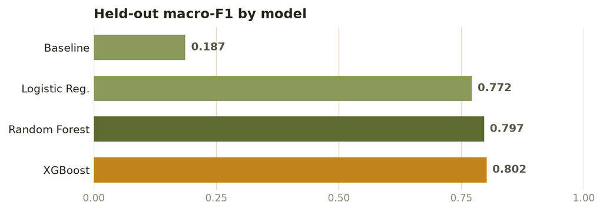

Figure 5.1: Held-out macro-F1 by model. XGBoost (gold) is the selected estimator.

## 5.2 Error structure

The model’s mistakes are almost entirely **adjacent-tier** confusions between neighbouring price bands (Figure 5.2). It virtually never confuses Budget with Premium — only 16 of 3,541 test listings (0.5 %) — which is exactly the failure profile a host can tolerate: a recommendation is rarely more than one tier away from the truth.

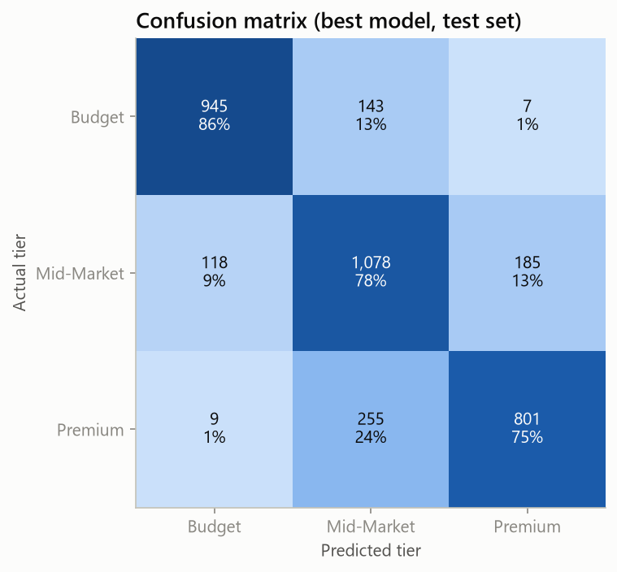

Figure 5.2: Confusion matrix on the held-out test set. Off-diagonal mass is concentrated on adjacent tiers; extreme (Budget vs. Premium) errors are negligible.

## 5.3 Feature importance

The most influential features (Figure 5.3) are the stay policy (`minimum_nights`), capacity (`bedrooms`, `accommodates`, `room_type`) and location (`longitude`, distance to CBD, distance to the nearest beach) — a ranking that aligns closely with the price determinants identified in hospitality research (Wang & Nicolau, 2017) and lends the model face validity.

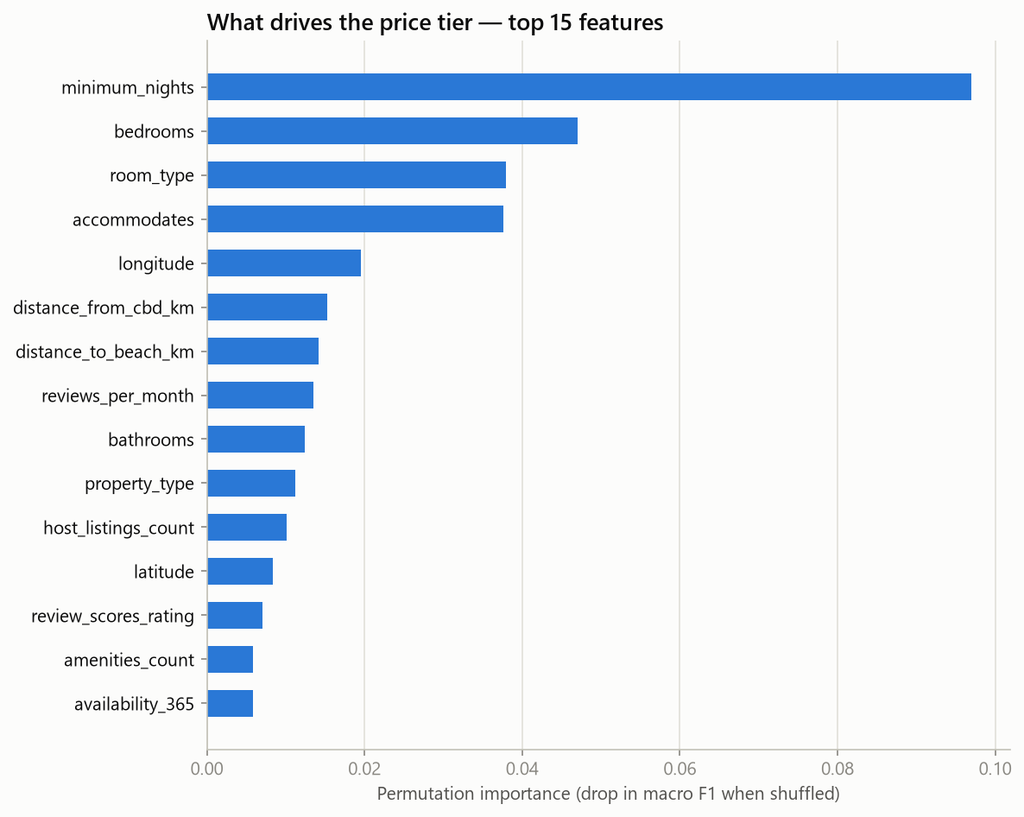

# 6 The interactive dashboard

The model is served through a Streamlit dashboard with two sections reached from an Airbnb-style top navigation (Figure 6.1).

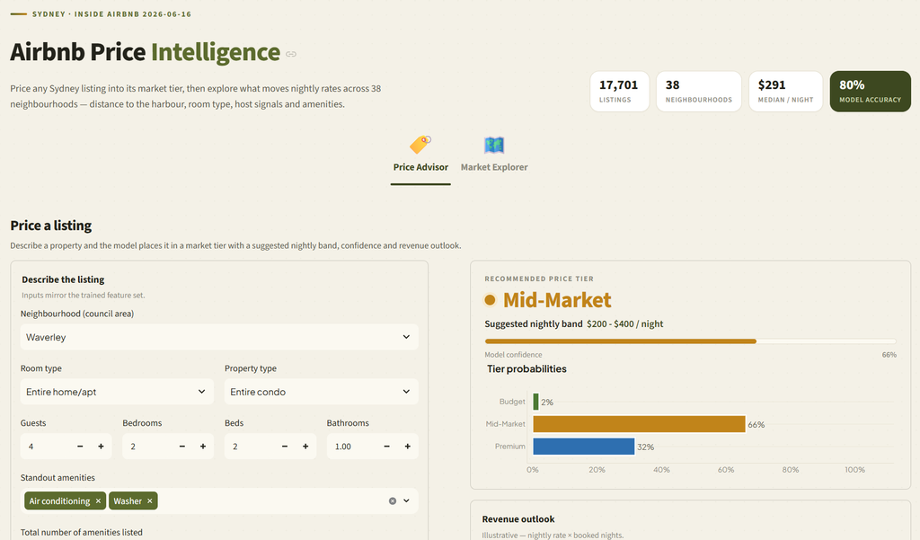

Figure 6.1: The dashboard landing view: headline metrics and the segmented Price Advisor / Market Explorer navigation.

The **Price Advisor** (Figure 6.2) takes a described listing and returns its recommended tier, a suggested nightly band, calibrated tier probabilities, an illustrative revenue outlook and a comparison against comparable listings in the same neighbourhood.

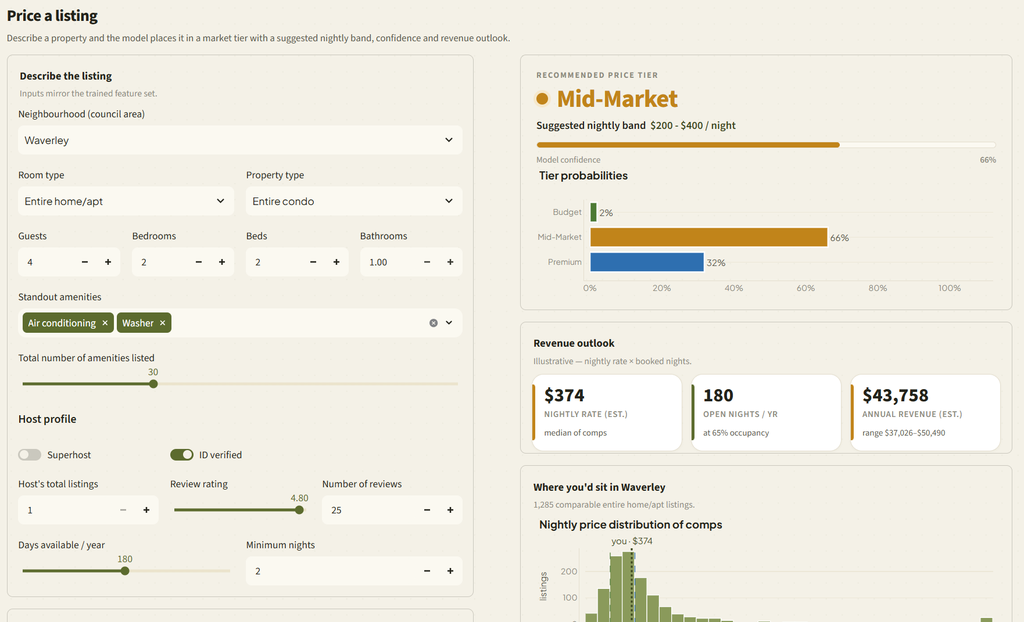

Figure 6.2: Price Advisor: listing inputs (left) and the model’s tier recommendation, confidence, revenue outlook and neighbourhood comparison (right).

The **Market Explorer** (Figure 6.3) provides a filterable view of the whole snapshot: a live KPI band, a price-tier map with per-listing hover, the priciest neighbourhoods, price distributions, the distance-to-CBD price decay, room-type tier mix and amenity premiums.

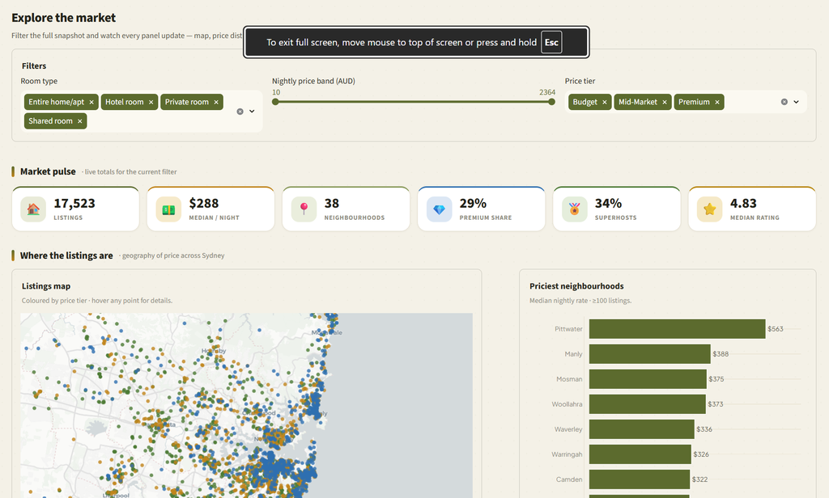

Figure 6.3: Market Explorer: filters, live KPIs, the price-tier listing map and neighbourhood price rankings.

All figures share one design system: a validated three-hue tier palette (green / amber / blue) that is colour-blind-safe, and interactive charts built with Plotly (Plotly Technologies Inc., 2015). Static analysis figures in this report are produced with Matplotlib (Hunter, 2007).

# 7 System architecture

The project is organised as a reproducible pipeline (Figure 7.1): a single command downloads the snapshot, cleans it, engineers features, trains and selects a model, and writes evaluation reports. A central configuration file exposes every parameter — snapshot date, tier thresholds, feature settings and model candidates — so experiments are reviewable in one place. One serving class, `PricingAdvisor`, is shared by the command-line interface, the dashboard and the test-suite, ensuring the code that serves predictions is identical to the code exercised by tests.

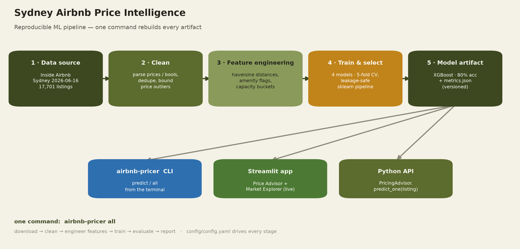

Figure 7.1: End-to-end architecture: a single command reproduces every artifact, and one serving path feeds the CLI, the dashboard and the Python API.

Correctness is enforced by 20 automated tests that run the real pipeline against a bundled sample of the actual snapshot — including a full training run and a disk round-trip of the model artifact — under continuous integration on Python 3.11–3.13.

# 8 Limitations

- **Asking, not transacted, prices.** Inside Airbnb records the price a host advertises, not the rate at which a booking clears; the tiers therefore model intended positioning rather than realised revenue.
- **Snapshot in time, single city.** The model reflects one Sydney snapshot and should be retrained per snapshot (a one-command operation) rather than reused with stale weights; it does not transfer directly to other cities.
- **Observable features only.** Unmodelled factors — photo quality, exact street, seasonality, special events — bound the achievable accuracy.
- **Decision support, not financial advice.** Outputs are intended to inform a host’s judgement, not to replace it.

# 9 Conclusion

Framing Airbnb pricing as a balanced, market-calibrated tier-classification problem yields a model that is accurate (79.8 %), interpretable and directly useful to a host. Just as importantly, the surrounding engineering — leakage-safe preprocessing, a single reproducible command, a shared serving path, automated tests and continuous integration — makes the result trustworthy and easy to re-run on each new data release. The accompanying dashboard turns the model into a product a non-technical host can actually use.

# 10 References

Chen, T., & Guestrin, C. (2016). XGBoost: A scalable tree boosting system. In *Proceedings of the 22nd ACM SIGKDD International Conference on Knowledge Discovery and Data Mining* (pp. 785–794). Association for Computing Machinery. https://doi.org/10.1145/2939672.2939785

Cox, M. (2026). *Inside Airbnb: Sydney* [Data set]. Inside Airbnb. Retrieved June 16, 2026, from https://insideairbnb.com/get-the-data/

Harris, C. R., Millman, K. J., van der Walt, S. J., Gommers, R., Virtanen, P., Cournapeau, D., Wieser, E., Taylor, J., Berg, S., Smith, N. J., Kern, R., Picus, M., Hoyer, S., van Kerkwijk, M. H., Brett, M., Haldane, A., del Río, J. F., Wiebe, M., Peterson, P., … Oliphant, T. E. (2020). Array programming with NumPy. *Nature, 585*(7825), 357–362. https://doi.org/10.1038/s41586-020-2649-2

Hunter, J. D. (2007). Matplotlib: A 2D graphics environment. *Computing in Science & Engineering, 9*(3), 90–95. https://doi.org/10.1109/MCSE.2007.55

Kalehbasti, P. R., Nikolenko, L., & Rezaei, H. (2021). Airbnb price prediction using machine learning and sentiment analysis. In A. Holzinger, P. Kieseberg, A. M. Tjoa, & E. Weippl (Eds.), *Machine Learning and Knowledge Extraction* (pp. 173–184). Springer. https://doi.org/10.1007/978-3-030-84060-0_11

McKinney, W. (2010). Data structures for statistical computing in Python. In *Proceedings of the 9th Python in Science Conference* (pp. 56–61). https://doi.org/10.25080/Majora-92bf1922-00a

Pedregosa, F., Varoquaux, G., Gramfort, A., Michel, V., Thirion, B., Grisel, O., Blondel, M., Prettenhofer, P., Weiss, R., Dubourg, V., Vanderplas, J., Passos, A., Cournapeau, D., Brucher, M., Perrot, M., & Duchesnay, É. (2011). Scikit-learn: Machine learning in Python. *Journal of Machine Learning Research, 12*, 2825–2830.

Plotly Technologies Inc. (2015). *Collaborative data science*. Plotly. https://plot.ly

Wang, D., & Nicolau, J. L. (2017). Price determinants of sharing economy based accommodation rental: A study of listings from 33 cities on Airbnb.com. *International Journal of Hospitality Management, 62*, 120–131. https://doi.org/10.1016/j.ijhm.2016.12.007